# Jordan algebras in R

Robin K. S. Hankin

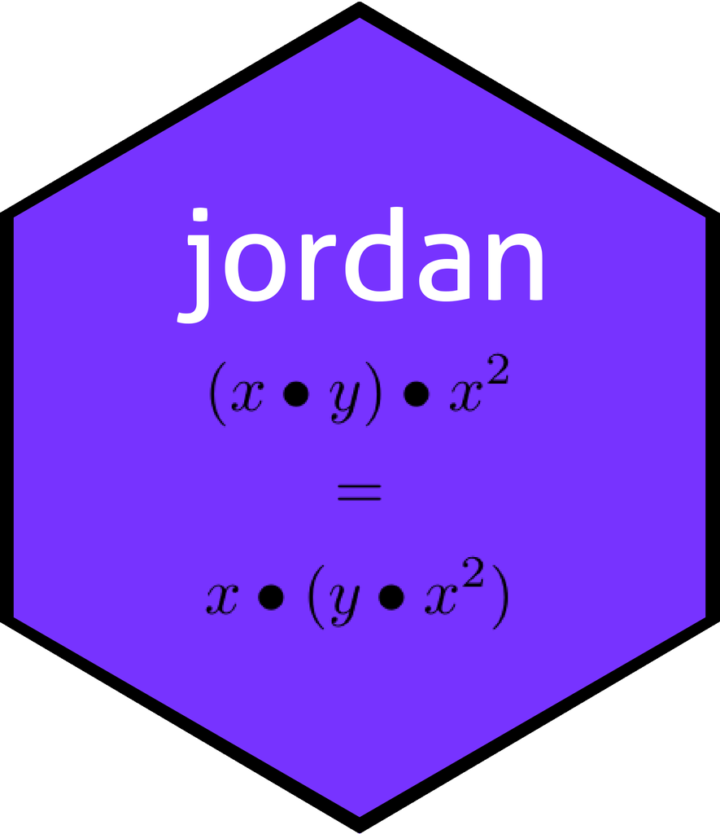

To cite the `jordan` package in publications please use Hankin (2023). Jordan algebras were originally introduced by Pascual Jordan in 1933 as an attempt to axiomatize observables in quantum mechanics. Formally, a *Jordan algebra* is a non-associative algebra over the reals with a bilinear multiplication that satisfies the following identities:

$$xy=yx$$

$$(xy)(xx)=x(y(xx))$$

(the second identity is known as the Jordan identity). In literature, multiplication is usually indicated by juxtaposition but one sometimes sees $x\bullet y$. Package idiom is to use an asterisk, as in `x*y`. Following McCrimmon (1978), there are five types of Jordan algebras:

- *type 1*: Real symmetric matrices, class `real_symmetric_matrix`, abbreviated in the package to `rsm`
- *type 2*: Complex Hermitian matrices, class `complex_herm_matrix`, abbreviated to `chm`
- *type 3*: Quaternionic Hermitian matrices, class `quaternion_herm_matrix`, abbreviated to `qhm`
- *type 4*: Albert algebras, the space of $3\times 3$ Hermitian octonionic matrices, class `albert`
- *type 5*: Spin factors, class `spin`

(of course, the first two are special cases of the next). The `jordan` package provides functionality to manipulate jordan objects using natural R idiom. Objects of all these classes are stored in matrix form with columns being elements of the jordan algebra. The first four classes are matrix-based in the sense that the algebraic objects are symmetric or Hermitian matrices (the S4 class is `jordan_matrix`). The fifth class, spin factors, is not matrix based.

# Matrix-based Jordan algebras, types 1,2,3

The four matrix-based Jordan algebras have elements which are square matrices. The first three classes are real (symmetric) matrices, complex (Hermitian) matrices, and quaternionic (Hermitian); type 4 is considered separately at the end. Types 1,2, and 3 all behave in the same way from a package idiom perspective. Consider:

```r
x <- rrsm()  # "Random Real Symmetric Matrix"
y <- rrsm()
z <- rrsm()
x
```

```
## Vector of real symmetric matrices with entries
##         [1]   [2]   [3]
##  [1,]  1.26 -0.41 -0.24
##  [2,] -0.33  0.25 -0.54
##  [3,]  1.33 -0.89 -0.43
##  [4,]  1.27  0.44 -0.65
##  [5,]  0.41 -1.24  0.73
## .......................
## [11,]  0.76  0.50  1.76
## [12,] -0.80  1.09  0.56
## [13,] -1.15 -0.69 -0.45
## [14,] -0.29 -1.28 -0.83
## [15,] -0.30  0.05 -1.17
```

Object `x` is a three-element vector, with each element being a column. Each element corresponds to a $5\times 5$ symmetric matrix (because `rrsm()` has `d=5` by default, specifying the size of the matrix). Thus each element has $5*(5+1)/2=15$ degrees of freedom, as indicated by the row labelling. Addition and multiplication of a Jordan object with a scalar are defined:

```r
x*100
```

```
## Vector of real symmetric matrices with entries
##        [1]  [2]  [3]
##  [1,]  126  -41  -24
##  [2,]  -33   25  -54
##  [3,]  133  -89  -43
##  [4,]  127   44  -65
##  [5,]   41 -124   73
## ....................
## [11,]   76   50  176
## [12,]  -80  109   56
## [13,] -115  -69  -45
## [14,]  -29 -128  -83
## [15,]  -30    5 -117
```

```r
x + y*3
```

```
## Vector of real symmetric matrices with entries
##         [1]   [2]   [3]
##  [1,] -1.95  0.67  3.06
##  [2,] -5.01  0.22 -0.12
##  [3,]  4.81 -3.71 -0.79
##  [4,]  3.76  0.08 -3.38
##  [5,] -0.28 -3.67 -3.59
## .......................
## [11,]  1.51  0.56  0.50
## [12,]  1.06  1.87  3.56
## [13,] -1.66 -2.64 -1.29
## [14,] -6.95 -1.64  2.95
## [15,] -4.08  2.03  0.78
```

```r
x + 100
```

```
## Vector of real symmetric matrices with entries
##          [1]    [2]    [3]
##  [1,] 101.26  99.59  99.76
##  [2,]  99.67 100.25  99.46
##  [3,] 101.33  99.11  99.57
##  [4,] 101.27 100.44  99.35
##  [5,] 100.41  98.76 100.73
## ..........................
## [11,] 100.76 100.50 101.76
## [12,]  99.20 101.09 100.56
## [13,]  98.85  99.31  99.55
## [14,]  99.71  98.72  99.17
## [15,]  99.70 100.05  98.83
```

(the last line is motivated by analogy with `M + x`, for `M` a matrix and `x` a scalar). Jordan objects may be multiplied using the rule $x\bullet y=(xy+yx)/2$:

```r
x*y
```

```
## Vector of real symmetric matrices with entries
##            [1]      [2]      [3]
##  [1,]  0.76410 -0.73630  0.75020
##  [2,] -2.95485 -0.11655  0.69915
##  [3,]  0.75970  2.17000 -0.84630
##  [4,] -0.74050 -0.61915  0.44255
##  [5,] -0.99495  0.58665 -0.43270
## ................................
## [11,]  0.25850  1.06925  2.00600
## [12,] -0.20925  0.17605 -0.78365
## [13,]  1.54600 -1.09150  0.20655
## [14,] -3.00675 -0.94800 -0.24035
## [15,]  0.91130  0.92850 -1.85950
```

We may verify that the distributive law is obeyed:

```r
x*(y+z) - (x*y + x*z)
```

```
## Vector of real symmetric matrices with entries
##                 [1]           [2]           [3]
##  [1,] -4.440892e-16  0.000000e+00  8.881784e-16
##  [2,]  0.000000e+00  2.220446e-16 -1.110223e-16
##  [3,]  0.000000e+00  4.440892e-16  0.000000e+00
##  [4,]  0.000000e+00  1.665335e-16 -2.220446e-16
##  [5,]  3.330669e-16  0.000000e+00 -1.665335e-16
## ...............................................
## [11,] -2.220446e-16  0.000000e+00 -4.440892e-16
## [12,] -2.220446e-16  3.330669e-16 -1.665335e-16
## [13,]  0.000000e+00 -3.330669e-16  8.881784e-16
## [14,] -8.881784e-16  1.110223e-16  4.440892e-16
## [15,]  0.000000e+00  1.110223e-16  2.220446e-16
```

(that is, zero to numerical precision). Further, we may observe that the resulting algebra is not associative:

```r
LHS <- x*(y*z)
RHS <- (x*y)*z
LHS-RHS
```

```
## Vector of real symmetric matrices with entries
##              [1]         [2]        [3]
##  [1,] -2.1017565 -1.19444550  0.7294260
##  [2,]  0.9831145  1.50253975 -0.9596110
##  [3,] -3.2116185 -0.89286100 -4.1190580
##  [4,]  0.2891320  1.10998775 -1.5859827
##  [5,] -1.8515115 -0.09683025 -0.8515705
## .......................................
## [11,] -0.2235020 -0.74325575  1.3072258
## [12,] -1.2445235  0.49372175 -0.2215460
## [13,]  0.1555397  0.27185050 -1.4434698
## [14,] -0.2530978 -0.70312400 -0.8658505
## [15,]  2.5612200 -0.15260950  1.8237820
```

showing numerically that $x(yz)\neq(xy)z$. However, the Jordan identity $(xy)(xx) = x(y(xx))$ is satisfied:

```r
LHS <- (x*y)*(x*x)
RHS <- x*(y*(x*x))
LHS-RHS
```

```
## Vector of real symmetric matrices with entries
##                 [1]           [2]           [3]
##  [1,]  1.776357e-15  0.000000e+00 -8.881784e-16
##  [2,]  0.000000e+00  0.000000e+00  4.440892e-16
##  [3,] -1.776357e-15  1.776357e-15 -2.220446e-16
##  [4,]  3.552714e-15 -4.440892e-16  0.000000e+00
##  [5,]  1.776357e-15  4.440892e-16  4.440892e-16
## ...............................................
## [11,]  8.881784e-16  0.000000e+00  1.776357e-15
## [12,]  2.664535e-15  2.220446e-16  4.440892e-16
## [13,] -1.776357e-15  0.000000e+00 -1.776357e-15
## [14,]  3.552714e-15  0.000000e+00 -1.776357e-15
## [15,] -1.776357e-15  8.881784e-16  0.000000e+00
```

(the entries are zero to numerical precision). If we wish to work with the matrix itself, a single element may be coerced with `as.1matrix()`:

```r
M1 <- as.1matrix(x[1])
(M2 <- as.1matrix(x[2]))
```

```
##       [,1]  [,2]  [,3]  [,4]  [,5]
## [1,] -0.41  0.25  0.44  0.38  0.50
## [2,]  0.25 -0.89 -1.24  0.13  1.09
## [3,]  0.44 -1.24 -0.22  0.80 -0.69
## [4,]  0.38  0.13  0.80 -0.06 -1.28
## [5,]  0.50  1.09 -0.69 -1.28  0.05
```

(in the above, observe how the matrix is indeed symmetric). We may verify that the multiplication rule is indeed being correctly applied:

```r
(M1 %*% M2 + M2 %*% M1)/2 - as.1matrix(x[1]*x[2])
```

```
##      [,1] [,2] [,3] [,4] [,5]
## [1,]    0    0    0    0    0
## [2,]    0    0    0    0    0
## [3,]    0    0    0    0    0
## [4,]    0    0    0    0    0
## [5,]    0    0    0    0    0
```

It is also possible to verify that symmetry is closed under the Jordan operation:

```r
jj <- as.1matrix(x[1]*x[2])
jj-t(jj)
```

```
##      [,1] [,2] [,3] [,4] [,5]
## [1,]    0    0    0    0    0
## [2,]    0    0    0    0    0
## [3,]    0    0    0    0    0
## [4,]    0    0    0    0    0
## [5,]    0    0    0    0    0
```

The other matrix-based Jordan algebras are similar but differ in the details of the coercion. Taking quaternionic matrices:

```r
as.1matrix(rqhm(n=1,d=2))
```

```
##    [1,1] [2,1] [1,2] [2,2]
## Re -0.96 -0.96 -0.96 -1.23
## i   0.00  0.87 -0.87  0.00
## j   0.00  0.91 -0.91  0.00
## k   0.00 -0.74  0.74  0.00
##      [,1] [,2]
## [1,]    1    3
## [2,]    2    4
```

above we see the matrix functionality of the `onion` package being used. See how the matrix is Hermitian (elements `[1,2]` and `[2,1]` are conjugate; elements `[1,1]` and `[2,2]` are pure real). Verifying the Jordan identity would be almost the same as above:

```r
x <- rqhm()
y <- rqhm()
(x*y)*(x*x) - x*(y*(x*x))
```

```
## Vector of quaternionic Hermitian matrices with entries
##                 [1]           [2]           [3]
##  [1,]  3.552714e-15  1.421085e-14  0.000000e+00
##  [2,] -2.131628e-14  1.421085e-14  3.552714e-15
##  [3,]  0.000000e+00  0.000000e+00  0.000000e+00
##  [4,]  5.329071e-15 -2.664535e-15 -7.105427e-15
##  [5,]  0.000000e+00  0.000000e+00  2.842171e-14
## ...............................................
## [41,]  8.437695e-15  8.881784e-15  0.000000e+00
## [42,] -1.421085e-14  0.000000e+00  5.329071e-15
## [43,] -7.105427e-15  1.421085e-14  8.881784e-15
## [44,] -3.552714e-15 -7.105427e-15  0.000000e+00
## [45,] -1.421085e-14  0.000000e+00  7.105427e-15
```

Above, we see that the difference is very small.

# Spin factors, type 5

The first four types of Jordan algebras are all matrix-based with either real, complex, quaternionic, or octonionic entries.

The fifth type, spin factors, are slightly different from a package idiom perspective. Mathematically, elements are of the form $\mathbb{R}\oplus\mathbb{R}^n$, with addition and multiplication defined by

$$\alpha(a,\mathbf{a}) = (\alpha
a,\alpha\mathbf{a})$$

$$(a,\mathbf{a}) + (b,\mathbf{b}) =
(a+b,\mathbf{a} + \mathbf{b})$$

$$(a,\mathbf{a}) \times (b,\mathbf{b}) =
(ab+\left\langle\mathbf{a},\mathbf{b}\right\rangle,a\mathbf{b} +
b\mathbf{a})$$

where $a,b,\alpha\in\mathbb{R}$, and $\mathbf{a},\mathbf{b}\in\mathbb{R}^n$. Here $\left\langle\cdot,\cdot\right\rangle$ is an inner product defined on $\mathbb{R}^n$ (by default we have $\left\langle(x_1,\ldots, x_n),(y_1,\ldots, y_n)\right\rangle=\sum x_iy_i$ but this is configurable in the package).

So if we have $\mathcal{I},\mathcal{J},\mathcal{K}$ spin factor elements it is clear that $\mathcal{I}\mathcal{J}=\mathcal{J}\mathcal{I}$ and $\mathcal{I}(\mathcal{J}+\mathcal{K}) = \mathcal{I}\mathcal{J} + \mathcal{I}\mathcal{K}$. The Jordan identity is not as easy to see but we may verify all the identities numerically:

```r
I <- rspin()
J <- rspin()
K <- rspin()
I
```

```
## Vector of spin objects with entries
##       [1]   [2]   [3]
##  r   0.14  0.91 -1.80
## [1] -0.34  1.14  0.37
## [2]  0.61  0.01 -0.38
## [3]  1.34 -1.11  0.65
## [4]  0.77 -0.03  2.06
## [5]  0.19 -0.16 -1.80
```

```r
I*J - J*I   # commutative:
```

```
## Vector of spin objects with entries
##     [1] [2] [3]
##  r    0   0   0
## [1]   0   0   0
## [2]   0   0   0
## [3]   0   0   0
## [4]   0   0   0
## [5]   0   0   0
```

```r
I*(J+K) - (I*J + I*K)  # distributive:
```

```
## Vector of spin objects with entries
##              [1]           [2]          [3]
##  r  4.440892e-16  0.000000e+00 1.776357e-15
## [1] 5.551115e-17 -8.881784e-16 0.000000e+00
## [2] 1.110223e-16  0.000000e+00 0.000000e+00
## [3] 4.440892e-16 -2.220446e-16 0.000000e+00
## [4] 2.220446e-16  4.440892e-16 0.000000e+00
## [5] 2.775558e-17  4.440892e-16 0.000000e+00
```

```r
I*(J*K) - (I*J)*K  # not associative:
```

```
## Vector of spin objects with entries
##               [1]           [2]       [3]
##  r  -2.220446e-16 -4.440892e-16  0.000000
## [1] -3.900790e-01 -1.625974e+00 -1.756489
## [2]  8.775930e-01  8.771170e-01 -5.327674
## [3]  2.349792e+00 -1.888707e+00  5.749035
## [4]  1.525986e+00 -1.707510e-01  3.378938
## [5]  4.767830e-01  5.984960e-01 -3.509500
```

```r
(I*J)*(I*I) - I*(J*(I*I))  # Obeys the Jordan identity
```

```
## Vector of spin objects with entries
##               [1]           [2]           [3]
##  r   6.661338e-16  0.000000e+00  0.000000e+00
## [1] -2.220446e-16  0.000000e+00  0.000000e+00
## [2]  0.000000e+00  8.881784e-16 -1.776357e-15
## [3]  4.440892e-16  0.000000e+00  0.000000e+00
## [4]  2.220446e-16 -8.881784e-16  0.000000e+00
## [5]  0.000000e+00  0.000000e+00  1.421085e-14
```

# Albert algebras, type 4

Type 4 Jordan algebra corresponds to $3\times 3$ Hermitian matrices with octonions for entries. This is class `albert` in the package. Note that octonionic Hermitian matrices of order 4 or above do not satisfy the Jordan identity and are therefore not Jordan algebras: there is a numerical illustration of this fact in the `onion` package vignette. We may verify the Jordan identity for $3\times 3$ octonionic Hermitian matrices using package class `albert`:

```r
x <- ralbert()
y <- ralbert()
x
```

```
## Vector of Albert matrices with entries
##          [1]   [2]   [3]
##     d1 -0.18 -0.26  0.03
##     d2  1.45 -0.06 -1.03
##     d3 -0.61 -0.45 -0.98
## Re(o1)  0.68  0.07  0.00
##  i(o1) -0.09 -0.15 -0.23
##  j(o1) -0.49 -0.83 -0.50
##  k(o1)  1.41  0.76  1.55
##  l(o1) -0.22 -0.58  0.09
## il(o1) -0.21 -0.63  1.32
## jl(o1)  0.70  0.48 -0.98
## kl(o1)  0.92  1.70 -0.25
## Re(o2) -0.92 -1.76 -1.40
##  i(o2)  1.15  0.20  1.44
##  j(o2) -0.64  0.40 -0.98
##  k(o2) -0.89  0.03  1.47
##  l(o2) -2.33  2.56 -0.99
## il(o2) -0.15  1.26 -0.09
## jl(o2)  0.32 -0.53 -2.88
## kl(o2) -0.71 -0.63 -0.25
## Re(o3)  1.24  0.91  0.01
##  i(o3)  0.62  1.01 -1.92
##  j(o3)  0.10  0.72 -0.29
##  k(o3)  1.81 -0.60 -0.35
##  l(o3) -1.50  0.54 -1.84
## il(o3)  0.29 -0.08  0.90
## jl(o3)  0.85  1.85 -1.21
## kl(o3) -1.00 -0.85 -0.22
```

```r
(x*y)*(x*x)-x*(y*(x*x)) # Jordan identity:
```

```
## Vector of Albert matrices with entries
##                  [1]           [2]           [3]
##     d1  1.421085e-14 -7.105427e-15  0.000000e+00
##     d2  1.421085e-14 -1.421085e-14  0.000000e+00
##     d3  2.842171e-14  1.421085e-14  0.000000e+00
## Re(o1) -1.776357e-15  8.881784e-16  2.131628e-14
##  i(o1) -7.105427e-15 -1.065814e-14  1.421085e-14
##  j(o1)  7.105427e-15  3.552714e-15  7.105427e-15
##  k(o1)  0.000000e+00  0.000000e+00 -7.105427e-15
##  l(o1)  7.105427e-15  0.000000e+00  5.329071e-15
## il(o1)  7.105427e-15 -3.552714e-15 -1.421085e-14
## jl(o1)  0.000000e+00 -7.105427e-15 -7.105427e-15
## kl(o1) -7.105427e-15 -1.421085e-14 -1.421085e-14
## Re(o2)  1.065814e-14 -1.421085e-14  0.000000e+00
##  i(o2)  0.000000e+00 -7.105427e-15 -7.105427e-15
##  j(o2)  0.000000e+00  0.000000e+00  1.421085e-14
##  k(o2)  1.421085e-14 -8.881784e-16 -2.842171e-14
##  l(o2) -7.105427e-15  0.000000e+00 -7.105427e-15
## il(o2) -7.105427e-15  0.000000e+00  0.000000e+00
## jl(o2) -3.552714e-15 -3.552714e-15 -1.421085e-14
## kl(o2)  3.552714e-15  1.776357e-15  9.769963e-15
## Re(o3)  3.552714e-15  0.000000e+00 -1.421085e-14
##  i(o3) -1.065814e-14  1.065814e-14  2.842171e-14
##  j(o3) -3.552714e-15  0.000000e+00 -7.105427e-15
##  k(o3) -5.107026e-15 -3.552714e-15 -7.105427e-15
##  l(o3)  8.881784e-15  1.421085e-14 -7.105427e-15
## il(o3)  1.776357e-14 -7.105427e-15 -1.421085e-14
## jl(o3)  0.000000e+00  0.000000e+00  1.421085e-14
## kl(o3)  7.105427e-15  0.000000e+00 -1.065814e-14
```

# Special identities

In 1963, C. M. Glennie discovered a pair of identities satisfied by special Jordan algebras but not the Albert algebra. Defining

$$U_x(y) = 2x(xy)-(xx)y$$

$$\left\lbrace x,y,z\right\rbrace=
2(x(yz)+(xy)z - (xz)y)$$

(it can be shown that Jacobson’s identity $U_{U_x(y)}=U_xU_yU_x$ holds), Glennie’s identities are

$$H_8(x,y,z)=H_8(y,x,z)\qquad H_9(x,y,z)=H_9(y,x,z)$$

$$H_8(x,y,z)= \left\lbrace U_x U_y(z),z, xy\right\rbrace-U_xU_yU_z(xy)$$

and
$$H_9(x,y,z)= 2U_x(z) U_{y,x}U_z(yy)-U_x U_z U_{x,y} U_y(z)$$

## Numerical verification of Jacobson

We may verify Jacobson’s identity:

```r
U <- function(x){function(y){2*x*(x*y)-(x*x)*y}}
diff <- function(x,y,z){
     LHS <- U(x)(U(y)(U(x)(z)))
     RHS <- U(U(x)(y))(z)
     return(LHS-RHS)  # zero if Jacobson holds
}
```

Then we may numerically verify Jacobson for type 3-5 Jordan algebras:

```r
diff(ralbert(),ralbert(),ralbert())  # Albert algebra obeys Jacobson:
```

```
## Vector of Albert matrices with entries
##                  [1]           [2]           [3]
##     d1  4.547474e-13  2.273737e-13  1.818989e-12
##     d2  7.958079e-13  1.591616e-12  0.000000e+00
##     d3  1.250555e-12 -4.547474e-13  3.637979e-12
## Re(o1) -1.136868e-13 -1.364242e-12  4.547474e-13
##  i(o1) -4.547474e-13 -2.273737e-13 -1.818989e-12
##  j(o1) -3.410605e-13  2.273737e-13  1.591616e-12
##  k(o1) -5.115908e-13  0.000000e+00 -1.364242e-12
##  l(o1)  2.273737e-13 -1.136868e-13  0.000000e+00
## il(o1)  5.684342e-13 -4.547474e-13  9.094947e-13
## jl(o1) -9.094947e-13  7.105427e-13 -1.364242e-12
## kl(o1) -6.821210e-13 -6.252776e-13 -1.818989e-12
## Re(o2)  1.136868e-13  0.000000e+00 -9.094947e-13
##  i(o2)  4.547474e-13  7.958079e-13  0.000000e+00
##  j(o2)  2.273737e-13 -1.136868e-13 -1.818989e-12
##  k(o2)  1.136868e-13  3.410605e-13  4.092726e-12
##  l(o2)  1.136868e-13  2.273737e-13  4.547474e-12
## il(o2)  2.273737e-13 -2.273737e-13  1.932676e-12
## jl(o2)  1.136868e-13  6.821210e-13 -4.547474e-13
## kl(o2)  2.273737e-13  2.273737e-13 -6.821210e-13
## Re(o3) -2.273737e-13  2.273737e-13  9.094947e-13
##  i(o3) -7.105427e-15 -9.094947e-13 -1.818989e-12
##  j(o3) -1.136868e-12  0.000000e+00  4.547474e-13
##  k(o3) -4.547474e-13 -4.547474e-13  4.547474e-13
##  l(o3)  1.364242e-12 -1.136868e-13  4.547474e-13
## il(o3)  5.684342e-13 -3.410605e-13 -9.094947e-13
## jl(o3)  0.000000e+00 -5.684342e-13 -1.136868e-12
## kl(o3)  1.136868e-13 -1.136868e-13  0.000000e+00
```

```r
diff(rqhm(),rqhm(),rqhm()) # Quaternion Jordan algebra obeys Jacobson:
```

```
## Vector of quaternionic Hermitian matrices with entries
##                 [1]           [2]           [3]
##  [1,]  2.728484e-12 -3.183231e-12 -4.547474e-12
##  [2,]  4.774847e-12  2.728484e-12 -4.547474e-12
##  [3,]  0.000000e+00 -5.911716e-12 -5.911716e-12
##  [4,]  1.818989e-12 -2.728484e-12 -7.275958e-12
##  [5,] -3.637979e-12 -5.456968e-12 -9.094947e-13
## ...............................................
## [41,]  1.364242e-12  4.092726e-12 -9.094947e-13
## [42,]  3.637979e-12  1.818989e-12  0.000000e+00
## [43,] -1.818989e-12  1.818989e-12 -9.094947e-13
## [44,]  2.273737e-13 -1.364242e-12  3.183231e-12
## [45,] -1.818989e-12  1.818989e-12  4.547474e-12
```

```r
diff(rspin(),rspin(),rspin()) # spin factors obey Jacobson:
```

```
## Vector of spin objects with entries
##               [1]           [2]           [3]
##  r   1.421085e-14 -5.151435e-14  0.000000e+00
## [1] -7.105427e-15  2.131628e-14  2.273737e-13
## [2]  0.000000e+00 -3.552714e-15 -1.136868e-13
## [3]  7.105427e-15  1.998401e-14  1.136868e-13
## [4]  0.000000e+00  5.329071e-15  2.131628e-13
## [5]  0.000000e+00 -7.105427e-15 -5.684342e-14
```

showing agreement to numerical accuracy (the output is close to zero). We can now verify Glennie’s $G_8$ and $G_9$ identities.

## Numerical verification of $G_8$

```r
B <- function(x,y,z){2*(x*(y*z) + (x*y)*z - (x*z)*y)}  # bracket function
H8 <- function(x,y,z){B(U(x)(U(y)(z)),z,x*y) - U(x)(U(y)(U(z)(x*y)))}
G8 <- function(x,y,z){H8(x,y,z)-H8(y,x,z)}
```

and so we verify for type 3 and type 5 Jordans:

```r
G8(rqhm(1),rqhm(1),rqhm(1))   # Quaternion Jordan algebra obeys G8:
```

```
## Vector of quaternionic Hermitian matrices with entries
##                 [1]
##  [1,]  0.000000e+00
##  [2,]  4.547474e-13
##  [3,] -5.456968e-12
##  [4,] -9.094947e-13
##  [5,]  2.182787e-11
## ...................
## [41,] -1.818989e-11
## [42,] -5.456968e-12
## [43,]  4.547474e-12
## [44,] -1.818989e-12
## [45,] -1.455192e-11
```

```r
G8(rspin(1),rspin(1),rspin(1)) # Spin factors obey G8:
```

```
## Vector of spin objects with entries
##                 a
##  r  -7.105427e-15
## [1]  0.000000e+00
## [2] -7.105427e-15
## [3] -7.105427e-15
## [4] -1.421085e-14
## [5]  2.842171e-14
```

again showing acceptable accuracy. The identity is *not* true for Albert algebras:

```r
G8(ralbert(1),ralbert(1),ralbert(1)) # Albert algebra does not obey G8:
```

```
## Vector of Albert matrices with entries
##               [1]
##     d1  -3548.756
##     d2   4725.027
##     d3  -1176.271
## Re(o1)  -9656.596
##  i(o1)   2084.501
##  j(o1)  -3042.062
##  k(o1) -11955.928
##  l(o1)   9874.819
## il(o1)  13939.995
## jl(o1)   2402.327
## kl(o1)  10258.985
## Re(o2)  -1897.960
##  i(o2) -18147.457
##  j(o2)  -9749.166
##  k(o2)  -5105.221
##  l(o2)   9852.301
## il(o2) -19952.518
## jl(o2)  -8786.434
## kl(o2)  -5976.901
## Re(o3)  12797.129
##  i(o3)  -5849.865
##  j(o3) -11008.285
##  k(o3)  -6832.751
##  l(o3)  12261.710
## il(o3)   5024.401
## jl(o3) -12186.564
## kl(o3)   -637.169
```

## Numerical verification of $G_9$

```r
L <- function(x){function(y){x*y}}
U <- function(x){function(y){2*x*(x*y)-(x*x)*y}}
U2 <- function(x,y){function(z){L(x)(L(y)(z)) + L(y)(L(x)(z)) - L(x*y)(z)}}
H9 <- function(x,y,z){2*U(x)(z)*U2(y,x)(U(z)(y*y)) - U(x)(U(z)(U2(x,y)(U(y)(z))))}
G9 <- function(x,y,z){H9(x,y,z)-H9(y,x,z)}
```

Then we may verify the `G9()` identity for type 3 Jordans:

```r
G9(rqhm(1),rqhm(1),rqhm(1))  # Quaternion Jordan algebra obeys G9:
```

```
## Vector of quaternionic Hermitian matrices with entries
##                 [1]
##  [1,]  1.164153e-10
##  [2,]  2.037268e-10
##  [3,] -1.455192e-10
##  [4,]  2.619345e-10
##  [5,]  2.328306e-10
## ...................
## [41,] -5.820766e-11
## [42,]  0.000000e+00
## [43,]  8.731149e-11
## [44,] -4.365575e-11
## [45,] -1.455192e-10
```

However, the Albert algebra does not satisfy the identity:

```r
G9(ralbert(1),ralbert(1),ralbert(1)) # Albert algebra does not obey G9:
```

```
## Vector of Albert matrices with entries
##                  [1]
##     d1   -7266.86356
##     d2   -8376.22006
##     d3 -176129.29514
## Re(o1)   63698.82453
##  i(o1) -113610.70700
##  j(o1)   18397.47508
##  k(o1)  -18360.14034
##  l(o1)  -53650.05517
## il(o1)    1693.22231
## jl(o1)   39312.82572
## kl(o1)   17003.00532
## Re(o2)  -43832.17576
##  i(o2)   15565.01374
##  j(o2)  -15984.80486
##  k(o2)   -5800.22870
##  l(o2)  -39014.58190
## il(o2)  -53929.49807
## jl(o2)  -47641.08428
## kl(o2)    7133.31837
## Re(o3)   12983.12738
##  i(o3)  -32369.08213
##  j(o3)     -85.85214
##  k(o3)     997.06029
##  l(o3)   44319.51887
## il(o3)  -32342.86674
## jl(o3)   46682.35665
## kl(o3)   40460.20737
```

## References

Hankin, Robin K. S. 2023. “Jordan Algebra in R.” arXiv. https://doi.org/10.48550/arXiv.2303.06062.

McCrimmon, K. 1978. “Jordan Algebras and Their Applications.” *Bulletin of the American Mathematical Society* 84 (4).